# Demo 1: Biomedical & Clinical Informatics

Merrimack College DSE6630: Healthcare & Life Sciences Analytics

Team Theta: Gregory Andriotakis

22 May 2025

# Introduction

You have just been brought on as a data science consultant for a patient advocacy watchdog. They have asked you to source information about hospital readmissions, because they would like to flag specific geographic areas or types of hospitals where hospital readmission is unexpectedly high. They have heard that datasets exist to investigate these types of questions, but they are not really sure where to begin.

You remember this one data science class you took - and the dataset from the **Centers for Medicare & Medicaid Services** managed by [Medicare.gov](https://www.medicare.gov). You start poking around the [Hospitals](https://data.cms.gov/provider-data/topics/hospitals) dataset and decide it is exactly what you need.

The problem is, this dataset is massive, so you are not only tasked with identifying a reasonable question you can ask from the dataset but managing the cleaning, pre-processing, and exploratory data analysis on the merged datasets you choose to explore.

## Question

For **Project 1**, you are going to choose your own question! But for this demo analysis, we are focusing on **pneumonia-related hospital readmissions**.

### Why pneumonia-related readmissions?

Hospital readmission rates for patients with pneumonia is almost unbelievably high, with about $\frac{1}{5}$ or 20% of patients hospitalized with pneumonia re-admitted within 30 days (de Alba and Amin, 2014). Further, pneumonia is both a leading cause of death among the elderly as well as a commonly communicated disease in hospitals (as in, people may come into a hospital for a different condition but be readmitted for pneumonia). Thus, given that pneumonia is the only communicable disease on this list, it is serving as our best proxy for diseases spread person-to-person within hospitals because of lack of availability.

#### Our research question:

Can we predict pneumonia-related hospital readmissions and, more generally, disease transfer within hospitals, based on hospital-level characteristics, including patient-ratings, Medicare money received, and other indicators of general performance in disease diagnosis and prevention?

#### Our hypothesis & prediction:

Hospitals are, by their very nature, hot zones for increased spread of disease, including pneumonia. We hypothesize that hospitals with lower indicators of patient care performance and lower Medicare funding rates will generally be unable to provide sufficient control of specific disease diagnosis and prevention, like pneumonia. This is because the same intrinsic and extrinsic factors that impact general patient quality of care is likely to extend to pneumonia, a *common, preventable, and treatable* disease. Thus, we specifically predict that factors indicating lower quality-of-care will predict higher than average rates of pneumonia-related hospital readmissions.

## Objective

Our objective for the patient advocacy watchdog is clean, merge, explore, and predict which hospitals tend to have higher-than-average rates of pneumonia-related readmissions. This is to enable the watchdog group to put together a dashboard or otherwise deploy this information to share with patients so they know how their local hospitals are performing, allowing them to make healthier, more informed choices.

# Data & Data Cleaning

1. Download the [Hospitals](https://data.cms.gov/provider-data/topics/hospitals) dataset as a zip directory.
2. Unzip the directory.
3. Make sure to adjust the name and/or path of the directory in your directory if it is different from mine. *Note that mine is living on my Desktop.*

**WARNING!** Do not try to put these data onto GitHub. They are too large to push. If you need help adjusting your path or have questions, please let me know.

```r
## Make sure to adjust your path!
filepath <- "~/Desktop/school/Healthcare/Week1/Demo1_NotGitHub/hospitals_current_data/"
```

### Read in the hospital-level data iteratively, while dynamically naming & storing each file as a dataframe.

You may have to dig through the accompanying data dictionary **HOSPITAL_Data_Dictionary.pdf** to get a better handle on what is in the hospital-level files.

##### **Question 1**: [1 point]

Take a look at the chunk below, which performs **dynamic variable assignment** as it reads in each of the files. Your task is to add a comment to each line of code to describe what that line does.

> Your answer in the code chunk as comments. Make sure to use the `#` sign!

```r
# Greg A.

files <- list.files(path = filepath, pattern = "Hospital.csv") # Creates a variable which stores the names of the hospital datafiles as a list

for(f in 1:length(files)) { # Starts a for loop, for each entry in the files list
    dat <- clean_names(read_csv(paste0(filepath, files[f]), # Clean each column name in the file, start by reading in the column names
                                show_col_types = FALSE), # Do not print out the names as they are read in
                       case = "upper_camel") # Apply upper camel casing to each column name
    filename <- gsub(".Hospital\\.csv", "", files[f]) # Remove .Hospital.csv from each file name
    assign(filename, dat) # Assign the cleaned name to the list
} # End the for loop

files <- gsub(".Hospital\\.csv", "", files) %>% data.frame() # Remove .Hospital.csv from each file name, convert the list into a dataframe
names(files) <- "File Name" # Give the column a name of "File Name" to clarify what we are looking at
```

#### Now, let’s look at a list of the files that we’ve read in:

Table 1. List of hospital-level data files.

| File Name |
| --- |
| Complications_and_Deaths |
| FY_2025_HAC_Reduction_Program |
| FY_2025_Hospital_Readmissions_Reduction_Program |
| HCAHPS |
| Health_Equity |
| Healthcare_Associated_Infections |
| Maternal_Health |
| Medicare_Hospital_Spending_Per_Patient |
| Outpatient_Imaging_Efficiency |
| Payment_and_Value_of_Care |
| Promoting_Interoperability |
| Timely_and_Effective_Care |
| Unplanned_Hospital_Visits |

##### **Question 2**: [1 point]

Take a look at some of the dataframes, e.g., `HCAHPS` and `FY_2024_Hospital_Readmissions_Reduction_Program`. What do you notice about the format / structure of the data? Does the data have an issue with the dimensionality? **Hint:** Check to see if each row represents a single line of data or not!

```r
# Greg A

head(HCAHPS) # Look at the first 6 rows of the dataframe
```

```
## # A tibble: 6 × 22
##   Facili…¹ Facil…² Address CityT…³ State ZipCode Count…⁴ Telep…⁵ Hcahp…⁶ Hcahp…⁷
##   <chr>    <chr>   <chr>   <chr>   <chr> <chr>   <chr>   <chr>   <chr>   <chr>
## 1 010001   SOUTHE… 1108 R… DOTHAN  AL    36301   HOUSTON (334) … H_COMP… "Patie…
## 2 010001   SOUTHE… 1108 R… DOTHAN  AL    36301   HOUSTON (334) … H_COMP… "Patie…
## 3 010001   SOUTHE… 1108 R… DOTHAN  AL    36301   HOUSTON (334) … H_COMP… "Patie…
## 4 010001   SOUTHE… 1108 R… DOTHAN  AL    36301   HOUSTON (334) … H_COMP… "Nurse…
## 5 010001   SOUTHE… 1108 R… DOTHAN  AL    36301   HOUSTON (334) … H_COMP… "Nurse…
## 6 010001   SOUTHE… 1108 R… DOTHAN  AL    36301   HOUSTON (334) … H_NURS… "Patie…
## # … with 12 more variables: HcahpsAnswerDescription <chr>,
## #   PatientSurveyStarRating <chr>, PatientSurveyStarRatingFootnote <dbl>,
## #   HcahpsAnswerPercent <chr>, HcahpsAnswerPercentFootnote <chr>,
## #   HcahpsLinearMeanValue <chr>, NumberOfCompletedSurveys <chr>,
## #   NumberOfCompletedSurveysFootnote <chr>, SurveyResponseRatePercent <chr>,
## #   SurveyResponseRatePercentFootnote <chr>, StartDate <chr>, EndDate <chr>,
## #   and abbreviated variable names ¹FacilityId, ²FacilityName, ³CityTown, …
```

```r
head(FY_2025_Hospital_Readmissions_Reduction_Program) # Look at the first 6 rows of the dataframe
```

```
## # A tibble: 6 × 12
##   Facili…¹ Facil…² State Measu…³ Numbe…⁴ Footn…⁵ Exces…⁶ Predi…⁷ Expec…⁸ Numbe…⁹
##   <chr>    <chr>   <chr> <chr>   <chr>     <dbl> <chr>   <chr>   <chr>   <chr>
## 1 SOUTHEA… 010001  AL    READM-… 296          NA 0.9483  13.0146 13.7235 36
## 2 SOUTHEA… 010001  AL    READM-… 151          NA 0.9509  9.6899  10.1898 13
## 3 SOUTHEA… 010001  AL    READM-… 681          NA 1.0597  21.5645 20.3495 151
## 4 SOUTHEA… 010001  AL    READM-… N/A          NA 0.9654  4.2680  4.4211  Too Fe…
## 5 SOUTHEA… 010001  AL    READM-… 490          NA 0.9715  16.1137 16.5863 77
## 6 SOUTHEA… 010001  AL    READM-… 130          NA 0.9330  15.4544 16.5637 16
## # … with 2 more variables: StartDate <chr>, EndDate <chr>, and abbreviated
## #   variable names ¹FacilityName, ²FacilityId, ³MeasureName,
## #   ⁴NumberOfDischarges, ⁵Footnote, ⁶ExcessReadmissionRatio,
## #   ⁷PredictedReadmissionRate, ⁸ExpectedReadmissionRate, ⁹NumberOfReadmissions
```

> Greg A. The data appears to be in long format, as opposed to the desired wide format. This means that each row does not represent a single hospital. Each row instead represents a single measure from a hospital.

### Tidy the data response variables’ dataframe: Fiscal Year 2024 Hospital Readmissions Reduction Program.

We are going to focus on the dataset `FY_2024_Hospital_Readmissions_Reduction_Program` to work on best practices to [tidy our data](https://vita.had.co.nz/papers/tidy-data.pdf). Although I do not personally choose to follow everything that Hadley Wickham and the **Tidy Data** Movement has espoused, I do think a lot of the best practices are useful principles especially when we are just getting use to working with data. Further, we can leverage a lot of the functions to make our lives MUCH easier! And who doesn’t like easier?!

##### **Question 3**: [1 point]

Take a deeper look at `FY_2024_Hospital_Readmissions_Reduction_Program` at some of the numeric variables in the dataset, e.g., `NumberOfReadmissions`?

```r
#Greg A.

dim(FY_2025_Hospital_Readmissions_Reduction_Program) # Look at the dimensions of the dataframe
```

```
## [1] 18510    12
```

```r
summary(FY_2025_Hospital_Readmissions_Reduction_Program) # Look at the summary statistics of the dataframe
```

```
##  FacilityName        FacilityId           State           MeasureName
##  Length:18510       Length:18510       Length:18510       Length:18510
##  Class :character   Class :character   Class :character   Class :character
##  Mode  :character   Mode  :character   Mode  :character   Mode  :character
##
##
##
##
##  NumberOfDischarges    Footnote     ExcessReadmissionRatio
##  Length:18510       Min.   :1.000   Length:18510
##  Class :character   1st Qu.:1.000   Class :character
##  Mode  :character   Median :5.000   Mode  :character
##                     Mean   :3.188
##                     3rd Qu.:5.000
##                     Max.   :7.000
##                     NA's   :11927
##  PredictedReadmissionRate ExpectedReadmissionRate NumberOfReadmissions
##  Length:18510             Length:18510            Length:18510
##  Class :character         Class :character        Class :character
##  Mode  :character         Mode  :character        Mode  :character
##
##
##
##
##   StartDate           EndDate
##  Length:18510       Length:18510
##  Class :character   Class :character
##  Mode  :character   Mode  :character
##
##
##
##
```

```r
head(FY_2025_Hospital_Readmissions_Reduction_Program) # Look at the first 6 rows of the dataframe
```

```
## # A tibble: 6 × 12
##   Facili…¹ Facil…² State Measu…³ Numbe…⁴ Footn…⁵ Exces…⁶ Predi…⁷ Expec…⁸ Numbe…⁹
##   <chr>    <chr>   <chr> <chr>   <chr>     <dbl> <chr>   <chr>   <chr>   <chr>
## 1 SOUTHEA… 010001  AL    READM-… 296          NA 0.9483  13.0146 13.7235 36
## 2 SOUTHEA… 010001  AL    READM-… 151          NA 0.9509  9.6899  10.1898 13
## 3 SOUTHEA… 010001  AL    READM-… 681          NA 1.0597  21.5645 20.3495 151
## 4 SOUTHEA… 010001  AL    READM-… N/A          NA 0.9654  4.2680  4.4211  Too Fe…
## 5 SOUTHEA… 010001  AL    READM-… 490          NA 0.9715  16.1137 16.5863 77
## 6 SOUTHEA… 010001  AL    READM-… 130          NA 0.9330  15.4544 16.5637 16
## # … with 2 more variables: StartDate <chr>, EndDate <chr>, and abbreviated
## #   variable names ¹FacilityName, ²FacilityId, ³MeasureName,
## #   ⁴NumberOfDischarges, ⁵Footnote, ⁶ExcessReadmissionRatio,
## #   ⁷PredictedReadmissionRate, ⁸ExpectedReadmissionRate, ⁹NumberOfReadmissions
```

> Greg A. What should be numerical columns feature NA values written out as character data instead of true NA values. In addition, there is a character value of ‘Too Few to Report’.

**Hint:** Columns 5 & 7:10 have problems with the `NA` class.

##### **Question 4**: [1 point]

Investigate the `replace_with_na_all()` function that is part of the `naniar` package. Use this function to fix the `NA` class in the aberrant columns in `FY_2024_Hospital_Readmissions_Reduction_Program`.

```r
# Greg A.

?replace_with_na_all # Pull up documentation for replace_with_na_all function
FY_2025_Hospital_Readmissions_Reduction_Program <- replace_with_na_all( # Apply the replace_with_na_all function on our dataset
  FY_2025_Hospital_Readmissions_Reduction_Program, condition = ~.x == "N/A") # fill NA values where there is text that reads "N/A"

head(FY_2025_Hospital_Readmissions_Reduction_Program) # Print the data so we can verify changes
```

```
## # A tibble: 6 × 12
##   Facili…¹ Facil…² State Measu…³ Numbe…⁴ Footn…⁵ Exces…⁶ Predi…⁷ Expec…⁸ Numbe…⁹
##   <chr>    <chr>   <chr> <chr>   <chr>     <dbl> <chr>   <chr>   <chr>   <chr>
## 1 SOUTHEA… 010001  AL    READM-… 296          NA 0.9483  13.0146 13.7235 36
## 2 SOUTHEA… 010001  AL    READM-… 151          NA 0.9509  9.6899  10.1898 13
## 3 SOUTHEA… 010001  AL    READM-… 681          NA 1.0597  21.5645 20.3495 151
## 4 SOUTHEA… 010001  AL    READM-… <NA>         NA 0.9654  4.2680  4.4211  Too Fe…
## 5 SOUTHEA… 010001  AL    READM-… 490          NA 0.9715  16.1137 16.5863 77
## 6 SOUTHEA… 010001  AL    READM-… 130          NA 0.9330  15.4544 16.5637 16
## # … with 2 more variables: StartDate <chr>, EndDate <chr>, and abbreviated
## #   variable names ¹FacilityName, ²FacilityId, ³MeasureName,
## #   ⁴NumberOfDischarges, ⁵Footnote, ⁶ExcessReadmissionRatio,
## #   ⁷PredictedReadmissionRate, ⁸ExpectedReadmissionRate, ⁹NumberOfReadmissions
```

You will notice that this aberrant class of missing value **caused** the numeric columns to be coerced into character columns when they were imported by `read_csv()`. Although we could try using `as.numeric()` by itself, which would assign `NA` to any non-numeric entry in `FY_2024_Hospital_Readmissions_Reduction_Program`, the problem is that we could lose important information that way. Thus, as annoying as this is, we should fix it a little more specifically…

##### **Question 5**: [1 point]

Look more closely at the `NumberOfReadmissions` column in the `FY_2024_Hospital_Readmissions_Reduction_Program`. What other issue do you see with this specific column that is coercing it to the character type, and why does it exist?

**Hint:** Make sure to use the accompanying data dictionary **HOSPITAL_Data_Dictionary.pdf** to also examine **WHY** this problem exists!

> Greg A. As noted earlier, there is another character entry of ‘Too Few to Report’. This is causing the should-be numeric columns to be considered character. Looking at the data dictionary, and remembering that each row represents a single measure, we can see why this kind of entry is made. According to the data dictionary, this message is added for the following reasons: 1. When the number of cases is too few for public reporting 2. When the number of cases is too small to reliably tell performance 3. To protect personal health information

##### **Question 6**: [1 point]

Investigate the `gsub()` function that is part of base `R` or any other function of your choosing. Use the function you choose to **replace** the problematic text in the `NumberOfReadmissions` column in `FY_2024_Hospital_Readmissions_Reduction_Program` with a **5**.

```r
# Greg A.
# This code is commented out so that it does not mess with knitting question 9.

?gsub # Pull up documentation for gsub function

# Apply the gsub function to the NumberofReadmissions column
# FY_2025_Hospital_Readmissions_Reduction_Program$NumberOfReadmissions <- gsub(
#  'Too Few to Report', 5, FY_2025_Hospital_Readmissions_Reduction_Program$NumberOfReadmissions) # Replace 'Too Few to Report' with 5

# head(FY_2025_Hospital_Readmissions_Reduction_Program) # Print the data so we can verify changes
```

##### **Question 7**: [1 point]

Speculate as to why I asked you to replace the text with a **5** rather than a **0** or an `NA`. Can you think of any other logical choices for the substitution? Do you agree with my choice? (You’re free to disagree, but please defend your decision either way!)

> Greg A. One reason to why a 5 was selected was so that we can later identify the value. Since 5 is a low value outside of the normal value range, it will not be confused for a legitimate entry. A 0 or NA might be confused as there being no value, which would cause a loss of information. Beyond a five, any small integer value above 0 could work, so long as it is outside of the normal value range.

##### **Question 8**: [1 point]

Now, imagine an alternative scenario where instead of replacing it with a **5**, I instead asked you to replace it with a randomly sampled integer from 1 to 10. What would this do? Would `gsub()` work here or would I need to execute it a different way, e.g., with an `lapply()` function or a `for()` loop?

> Greg A. gsub() would not work for this application, because it expects a single value. Since it expects a single value, we are unable to apply a randomly sampled integer.

##### **Question 9**: [3 points]

You probably anticipated this! We just decided that, rather than a **5** we want a randomly sampled integer from 1 to 10.

**Hint 1:** You might find it easier to read the data in from fresh and, after commenting out your `gsub` from Question 5, pattern match on the problematic text.

**Hint 2:** This is NOT the only way to do this, but I solved this using `gregexpr()`, `regmatches()`, and `lapply()`.

```r
# Greg A.
# Before running this code, I reran the previous code, excluding the gsub chunk, as suggested.

FY_2025_Hospital_Readmissions_Reduction_Program$NumberOfReadmissions <- unlist(lapply( # Use lapply to loop through each row in the column
    FY_2025_Hospital_Readmissions_Reduction_Program$NumberOfReadmissions, function(x) { # For each row, apply the following
  if (is.na(x)) {x} # If the value is NA, return the original value
  else if (x == "Too Few to Report") {sample(1:10, 1)} # If the value is "Too Few to Report", replace it with a random integer between 1 and 10
  else {x} # If neither, return the original value
}))

head(FY_2025_Hospital_Readmissions_Reduction_Program) # Print the data so we can verify changes
```

```
## # A tibble: 6 × 12
##   Facili…¹ Facil…² State Measu…³ Numbe…⁴ Footn…⁵ Exces…⁶ Predi…⁷ Expec…⁸ Numbe…⁹
##   <chr>    <chr>   <chr> <chr>   <chr>     <dbl> <chr>   <chr>   <chr>   <chr>
## 1 SOUTHEA… 010001  AL    READM-… 296          NA 0.9483  13.0146 13.7235 36
## 2 SOUTHEA… 010001  AL    READM-… 151          NA 0.9509  9.6899  10.1898 13
## 3 SOUTHEA… 010001  AL    READM-… 681          NA 1.0597  21.5645 20.3495 151
## 4 SOUTHEA… 010001  AL    READM-… <NA>         NA 0.9654  4.2680  4.4211  1
## 5 SOUTHEA… 010001  AL    READM-… 490          NA 0.9715  16.1137 16.5863 77
## 6 SOUTHEA… 010001  AL    READM-… 130          NA 0.9330  15.4544 16.5637 16
## # … with 2 more variables: StartDate <chr>, EndDate <chr>, and abbreviated
## #   variable names ¹FacilityName, ²FacilityId, ³MeasureName,
## #   ⁴NumberOfDischarges, ⁵Footnote, ⁶ExcessReadmissionRatio,
## #   ⁷PredictedReadmissionRate, ⁸ExpectedReadmissionRate, ⁹NumberOfReadmissions
```

##### **Question 10**: [1 point]

It is finally time to fix those aberrant character columns by making them numeric. However, just using `as.numeric()` would require us to do it over and over on each of the columns in multiple lines of code. Instead, investigate the function `mutate_at()` which will allow you to pass it a list of columns you want to convert with the function you want to use.

```r
# Greg A.

?mutate_at # Pull up documentation for mutate_at function
FY_2025_Hospital_Readmissions_Reduction_Program <- FY_2025_Hospital_Readmissions_Reduction_Program %>% # Apply the following to the dataframe
  mutate_at(vars(NumberOfDischarges, ExcessReadmissionRatio, PredictedReadmissionRate, # Alter the following columns
                 ExpectedReadmissionRate, NumberOfReadmissions), as.numeric) # Set the columns as numeric

head(FY_2025_Hospital_Readmissions_Reduction_Program) # Print the data so we can verify changes
```

```
## # A tibble: 6 × 12
##   Facili…¹ Facil…² State Measu…³ Numbe…⁴ Footn…⁵ Exces…⁶ Predi…⁷ Expec…⁸ Numbe…⁹
##   <chr>    <chr>   <chr> <chr>     <dbl>   <dbl>   <dbl>   <dbl>   <dbl>   <dbl>
## 1 SOUTHEA… 010001  AL    READM-…     296      NA   0.948   13.0    13.7       36
## 2 SOUTHEA… 010001  AL    READM-…     151      NA   0.951    9.69   10.2       13
## 3 SOUTHEA… 010001  AL    READM-…     681      NA   1.06    21.6    20.3      151
## 4 SOUTHEA… 010001  AL    READM-…      NA      NA   0.965    4.27    4.42       1
## 5 SOUTHEA… 010001  AL    READM-…     490      NA   0.972   16.1    16.6       77
## 6 SOUTHEA… 010001  AL    READM-…     130      NA   0.933   15.5    16.6       16
## # … with 2 more variables: StartDate <chr>, EndDate <chr>, and abbreviated
## #   variable names ¹FacilityName, ²FacilityId, ³MeasureName,
## #   ⁴NumberOfDischarges, ⁵Footnote, ⁶ExcessReadmissionRatio,
## #   ⁷PredictedReadmissionRate, ⁸ExpectedReadmissionRate, ⁹NumberOfReadmissions
```

#### Let’s look more closely at Measure Names.

Notice, that what I have done here first is used the `gsub()` function to `mutate()` the `MeasureName` column to remove the text that flanked the medical conditions.

```r
FY_2025_Hospital_Readmissions_Reduction_Program <-  FY_2025_Hospital_Readmissions_Reduction_Program %>%
  mutate(MeasureName = gsub("READM-30-", "", MeasureName)) %>%
  mutate(MeasureName = gsub("-HRRP", "", MeasureName))
```

**Note:** If at this point you’ve had any issues with any of the previous problems 2-10, you can load the cleaned readmissions data, `readmissionsClean.Rdata` so that you can proceed with the assignment.

```r
load(file = "readmissionsClean.Rdata")
```

##### **Question 11**: [1 point]

Investigate the function `pivot_wider()` or `spread()` from the `tidyr` package, which comes bundled with `tidyverse`. Try pivoting the `FY_2024_Hospital_Readmissions_Reduction_Program` dataset wider. Make sure you correctly identify the `names_from` and `values_from` column(s). **Make sure to save it as a separate dataframe called `wideDF`.** Use the `dim()` function to prove to me that you successfully pivoted wider.

```r
# Greg A.

?pivot_wider # Pull up documentation for pivot_wider function

wideDF <- FY_2025_Hospital_Readmissions_Reduction_Program %>% # Create wideDF from FY_2025_Hospital_Readmissions_Reduction_Program
  pivot_wider( # Pivot to wide format based on the following
    id_cols = c(FacilityName, FacilityId, State), # These columns are identifiers
    names_from = MeasureName, # Column names will come from MeasureName
    values_from = c(ExcessReadmissionRatio, PredictedReadmissionRate, ExpectedReadmissionRate) # Column values will be filled in from ExcessReadmissionRatio, PredictedReadmissionRate, and ExpectedReadmissionRate
  )


dim(wideDF) # Display the dimensions of the wide data
```

```
## [1] 3085   21
```

```r
head(wideDF) # Display the first 6 rows
```

```
## # A tibble: 6 × 21
##   Facili…¹ Facil…² State Exces…³ Exces…⁴ Exces…⁵ Exces…⁶ Exces…⁷ Exces…⁸ Predi…⁹
##   <chr>    <chr>   <chr>   <dbl>   <dbl>   <dbl>   <dbl>   <dbl>   <dbl>   <dbl>
## 1 SOUTHEA… 010001  AL      0.948   0.951   1.06    0.965   0.972   0.933    13.0
## 2 MARSHAL… 010005  AL     NA      NA       0.994   0.850   0.850   0.870    NA
## 3 NORTH A… 010006  AL      0.970   1.08    0.967   0.976   1.01    0.946    11.9
## 4 MIZELL … 010007  AL     NA      NA       1.07    0.970   1.05    1.03     NA
## 5 CRENSHA… 010008  AL     NA      NA      NA      NA      NA      NA        NA
## 6 ST. VIN… 010011  AL      0.968   1.11    1.04    0.954   1.06    1.01     11.9
## # … with 11 more variables: PredictedReadmissionRate_CABG <dbl>,
## #   PredictedReadmissionRate_HF <dbl>,
## #   `PredictedReadmissionRate_HIP-KNEE` <dbl>,
## #   PredictedReadmissionRate_PN <dbl>, PredictedReadmissionRate_COPD <dbl>,
## #   ExpectedReadmissionRate_AMI <dbl>, ExpectedReadmissionRate_CABG <dbl>,
## #   ExpectedReadmissionRate_HF <dbl>, `ExpectedReadmissionRate_HIP-KNEE` <dbl>,
## #   ExpectedReadmissionRate_PN <dbl>, ExpectedReadmissionRate_COPD <dbl>, and …
```

### Filtering for specific conditions.

Ideally, though, before we’d pivot wider we would decide if we were going to filter for any specific hospital readmission conditions. For your **Project 1**, you will be choosing which medical condition(s) you want to focus on for predicting hospital readmission. However, for the remainder of this demo, we’re going to focus on just **pneumonia**.

**Ideas you might consider for your Project_1 are:**

- surgical interventions (`HIP-KNEE`, `CABG`)
- heart-related conditions (`HF`, `AMI`, & `CABG`)
- all conditions (warning: this might be too unwieldy!)
- any other condition(s) that you motivate with a statement or two in support

Therefore, let’s filter for just pneumonia-related readmissions which will actually eliminate the need to pivot wider in just this case (because we only chose a single condition).

```r
readmissionsClean <-
  readmissionsClean %>%
  filter(MeasureName == "PN")
```

Table 2. Acronyms of medical conditions for which hospital readmissions are tracked.

| Acronym | Definition |
| --- | --- |
| HIP-KNEE | Total Hip/Knee Arthroplasty |
| HF | Heart Failure |
| COPD | Chronic Obstructive Pulmonary Disease |
| AMI | Acute Myocardial Infarction |
| CABG | Coronary Artery Bypass Graft |
| PN | Pneumonia |

It’s important to understand that these medical conditions are the **ones that Medicaid/Medicare tracks for hospital readmissions**. These are not the only conditions in which a patient might be readmitted, but these are the ones that the agency uses to keep track of hospital performance.

### Dynamic creation of merged dataframe objects: supporting dataframes.

We will often be asked to deal with large, unwieldy datasets and sometimes we need to be able to handle them dynamically. **Dynamic variable assignment**, as I demonstrated when we read in the files, is going to come in handy - but it can sometimes be tricky to accomplish. The whole point, though, is to create code that can handle ANYTHING you throw at it.

In a similar vein, we can also perform **dynamic dataframe creation** when we need to modify and stitch together more than one pre-existing dataframe - ESPECIALLY when we might decide down the line to alter our choices by adding or removing other dataframes.

#### Writing your own function to create objects dynamically.

We are going to take all the cleaning steps we did above that was not specific to the `FY_2024_Hospital_Readmissions_Reduction_Program` dataframe and tidy, pivot, & filter for specific readmission conditions, and iteratively join as many dataframes as needed. The goal is to make something flexible enough that, if you change a set of inputs, it will create a joined table from ANY set of dataframe inputs. There is more than one way to do this; but leveraging some of the existing `tidyverse` and `tidyr` functions will likely help you make this very flexible. Please note, however, that you do not have to use those packages.

I start you out with something I find helpful when joining together dataframes that sometimes have *redundant* columns BUT not every column is in every dataframe. I start by making a dataframe called `hospitalInfo` that contains the pertinent information on each hospital in the dataset, so you can drop those columns from the other dataframes to prevent inflation or issues when you later join the dataframes together. You may want to join each of the other dataframes to `hospitalInfo`.

As I was writing my own version of this function, I found that the `Payment and Value of Care` table must be separated into two tables to join well, at least with how I wrote my function. So, I do that for you below. I also clean up `HCAHPS` to make it easier to work for the function I wrote, so it may also be useful for you. Note that what I’m doing in these cases is making sure that `MeasureName` is the title of the column **I will join my tables on.** In this way, I’m using the `MeasureName` as the **key** for my table joins.

**First, make sure to separate the Payment and Values tables, giving each facility IDs:**

```r
paymentOnly <- Payment_and_Value_of_Care %>%
  select(FacilityId, PaymentMeasureName, PaymentCategory, Payment) %>%
  mutate(Payment = gsub("\\$", "", Payment)) %>% # Remove the dollar sign
  mutate(Payment = gsub("\\,", "", Payment)) %>% # Remove the comma
  rename(MeasureName = PaymentMeasureName)  # Make consistent with other tables

valueOnly <- Payment_and_Value_of_Care %>%
  select(FacilityId, ValueOfCareDisplayName, ValueOfCareCategory) %>%
  rename(MeasureName = ValueOfCareDisplayName)  # Make consistent with other tables
```

**HCAHPS is also a mess. Remove the columns that we will never use in any analysis, make a `MeasureName` column, and also drop the ” - linear mean score” from some rows in the newly minted `MeasureName`**

```r
HCAHPS <- HCAHPS %>%
  select(-HcahpsMeasureId, -PatientSurveyStarRatingFootnote,
         -HcahpsAnswerPercentFootnote, -NumberOfCompletedSurveysFootnote,
         -SurveyResponseRatePercentFootnote, -HcahpsAnswerDescription,
         -PatientSurveyStarRating) %>%  ## Drops the columns we don't need
  rename(MeasureName = HcahpsQuestion) %>%  ## Makes a new MeasureName column
  mutate(MeasureName = gsub(" - linear mean score", "", MeasureName))
  ## Takes off the phrase that we don't want
```

**Lastly, pull the hospital information off of the Payment and Value table because it is complete there. We can then drop this information from all the other tables:**

```r
hospitalInfo <- Payment_and_Value_of_Care %>%
              ## Information about the hospitals
                select(FacilityId, FacilityName, Address, CityTown,
                         State, ZipCode, CountyParish, TelephoneNumber)
```

##### **Question 12**: [5 points]

Write a function that will:

1. Fix any issues identified previously, e.g., issues with the `NA` class or pivoting, if needed
2. Join any number of a list of dataframes you give it. For example, it should be able to join these 8 tables:

```r
datList <- list(Healthcare_Associated_Infections,
                paymentOnly,
                Outpatient_Imaging_Efficiency,
                Complications_and_Deaths,
                Medicare_Hospital_Spending_Per_Patient,
                Timely_and_Effective_Care,
                Unplanned_Hospital_Visits,
                HCAHPS)
```

3. Filters the data for given criteria and condition(s) prior to pivoting. For example, for the 8 tables listed above, perhaps to filter for these possible measures before pivoting, so that I’m not pivoting ALL of those measures! (That would likely crash R!). Notice that what we’re filtering for - is really a selection criteria, but because the data are in **wide format**, we are selecting them by row (i.e., “filter”) rather than selection by column (i.e., “select”).

```r
filterList <- list("MRSA Bacteremia",
                   "Payment for pneumonia patients",
                   "Abdomen CT Use of Contrast Material",

                   c("Death rate for pneumonia patients",
                     "Perioperative pulmonary embolism or deep vein thrombosis rate",
                     "CMS Medicare PSI 90: Patient safety and adverse events composite",
                     "Postoperative respiratory failure rate"),

                   "Medicare spending per patient",

                   c("Healthcare workers given influenza vaccination",
                     "Percentage of healthcare personnel who completed COVID-19 primary vaccination series",
                     "Average (median) time patients spent in the emergency department before leaving from the visit A lower number of minutes is better",
                     "Left before being seen",
                     "Venous Thromboembolism Prophylaxis",
                     "Intensive Care Unit Venous Thromboembolism Prophylaxis",
                     "Emergency department volume"),

                   "Hospital return days for pneumonia patients",

                   c("Nurse communication",
                     "Doctor communication",
                     "Staff responsiveness",
                     "Communication about medicines",
                     "Discharge information",
                     "Care transition",
                     "Cleanliness",
                     "Quietness",
                     "Overall hospital rating",
                     "Recommend hospital")
)
```

4. For full credit, make sure that your function can clean up and join together at least three of the dataframes. **Note**: Make sure to join with `readmissionsClean` at the end!

Perhaps you will choose to start your function like this (although you do not have to):

```r
tidyNjoin <- function(datList, filterList, hospitalInfo) {

}
```

- **Hint 1:** Feel free to drop the `startDate` and `endDate` columns, as well as the `footnote` column. I would even suggest dropping `MeasureId`.
- **Hint 2:** `select(-any_of(c(...)))` can be used to drop any of a list of columns, regardless of whether it exists in every dataframe or not.
- **Hint 3:** If you choose to drop all those extraneous columns, then the column you will need to merge/join on will always be in the second position, `MeasureName`.
- **Hint 4:** `full_join()` in `dplyr` is likely what you will need; you will want to execute the join on `FacilityId`.
- **Hint 5:** Make sure to check for and/or remove duplicate rows.
- **Hint 6:** If you are really stuck, move ahead and I give you a cleaned, merged data set to work with.

Okay, take a stab at it!

```r
# Greg A.

tidyNjoin <- function(datList, filterList, hospitalInfo) { # Create the function tidyNjoin with the parameters datList, filterList, and hospitalInfo

  tidy_one <- function(df, filter_condition) { # Create tidy function

    df <- df %>% # Drop the following columns if they exist
      select(-any_of(c("StartDate", "EndDate", "Footnote", "MeasureId")))

    df <- replace_with_na_all(df, condition = ~.x == "N/A") # Convert NA values to true NA values

    # Impute "Too Few to Report" if NumberOfReadmissions exists
    if ("NumberOfReadmissions" %in% names(df)) {
      df$NumberOfReadmissions <- unlist(lapply(
        df$NumberOfReadmissions, function(x) {
          if (is.na(x)) { x }
          else if (x == "Too Few to Report") { sample(1:10, 1) }
          else { x }
        }
      ))
    }

    num_cols <- intersect( # Convert following columns to numeric type
      c("NumberOfDischarges", "ExcessReadmissionRatio",
        "PredictedReadmissionRate", "ExpectedReadmissionRate",
        "NumberOfReadmissions"),
      names(df)
    )
    df <- df %>%
      mutate(across(all_of(num_cols), as.numeric))

    if ("MeasureName" %in% names(df)) { # Filter for MeasureName
      df <- df %>% filter(MeasureName %in% filter_condition)
    }

    if (all(c("FacilityId", "MeasureName") %in% names(df))) { # Remove duplicate rows
      df <- df %>% distinct(FacilityId, MeasureName, .keep_all = TRUE)
    } else if ("FacilityId" %in% names(df)) {
      df <- df %>% distinct(FacilityId, .keep_all = TRUE)
    }

    if ("MeasureName" %in% names(df)) { # Pivot data into wide format
      id_cols <- "FacilityId"
      value_cols <- setdiff(names(df), c("FacilityId", "MeasureName"))
      df <- df %>%
        pivot_wider(
          id_cols = all_of(id_cols),
          names_from = MeasureName,
          values_from = all_of(value_cols)
        )
    }

    return(df) # Return tidy data
  }

  tidied_dfs <- mapply( # Apply tidying to each dataframe
    tidy_one,
    df = datList,
    filter_condition = filterList,
    SIMPLIFY = FALSE
  )

  joined_df <- Reduce(function(x, y) full_join(x, y, by = "FacilityId"), tidied_dfs) # Full join on FacilityId

  joined_df <- joined_df %>% distinct(FacilityId, .keep_all = TRUE) # Remove duplicate rows

  final_df <- left_join(joined_df, hospitalInfo, by = "FacilityId") # Join with hospitalInfo on FacilityId

  return(final_df) # Return final version of the data
}
```

```r
# Greg A.

datList_small <- lapply(datList, function(hospitalInfo) head(hospitalInfo, 100)) # Create smaller datList for speedy testing
result <- tidyNjoin(datList_small, filterList, hospitalInfo) # Apply custom function to small datList, filterList, and hospitalInfo
head(result) # Display first 6 rows of results
```

```
## # A tibble: 6 × 259
##   FacilityId FacilityN…¹ Addre…² CityT…³ State…⁴ ZipCo…⁵ Count…⁶ Telep…⁷ Compa…⁸
##   <chr>      <chr>       <chr>   <chr>   <chr>   <chr>   <chr>   <chr>   <chr>
## 1 010001     SOUTHEAST … 1108 R… DOTHAN  AL      36301   HOUSTON (334) … Better…
## 2 010001     SOUTHEAST … 1108 R… DOTHAN  AL      36301   HOUSTON (334) … Better…
## 3 010001     SOUTHEAST … 1108 R… DOTHAN  AL      36301   HOUSTON (334) … Better…
## 4 010001     SOUTHEAST … 1108 R… DOTHAN  AL      36301   HOUSTON (334) … Better…
## 5 010005     MARSHALL M… 2505 U… BOAZ    AL      35957   MARSHA… (256) … No Dif…
## 6 010005     MARSHALL M… 2505 U… BOAZ    AL      35957   MARSHA… (256) … No Dif…
## # … with 250 more variables: `Score_MRSA Bacteremia` <chr>,
## #   `PaymentCategory_Payment for pneumonia patients` <chr>,
## #   `Payment_Payment for pneumonia patients` <chr>,
## #   `FacilityName_Abdomen CT Use of Contrast Material` <chr>,
## #   `Address_Abdomen CT Use of Contrast Material` <chr>,
## #   `CityTown_Abdomen CT Use of Contrast Material` <chr>,
## #   `State_Abdomen CT Use of Contrast Material` <chr>, …
```

##### **Question 13**: [1 point]

Why do you think I just made you work through this function? (**Hint**: What are you going to be asked to do in Project 1?)

> Greg A. This function gives us the ability to tidy, filter, pivot, and join as many tables as necessary. In project 1, we will be selecting which conditions we wish to focus on. Creating this function now will help us in project 1, as it will allow us to easily select what we wish to focus on and transform it in these ways without having to manually go through the coding process.

### The full, merged, tidied dataset for pneumonia.

Please load if you are struggling to get a function that performs the task or if you aren’t sure if it does what’s expected.

```r
load("pneumoniaFull.Rdata")
dim(pneumoniaFull)
```

```
## [1] 4816  100
```

As I mentioned in Question 12, I ultimately chose to merge 8 of the datasets together for this dataset, although I selectively filtered to focus on my question: **Can we predict pneumonia-related hospital readmissions based on factors that might indicate how well the hospital is doing at diagnostics and disease prevention?**

Whew! Notice that this dataset currently has **100 features** and **4,816 rows**. That’s definitely too many features, so let’s perform some additional feature selection.

**Let’s start by examining the “big picture” of what’s in this giant dataset**:

Table 3. List of hospital-level data sets chosen for the pneumonia-related readmissions analysis.

| Dataset | Information Used | Rationale |
| --- | --- | --- |
| Healthcare_Associated_Infections | MRSA Bacteremia | Hospital-transmitted disease rate |
| paymentOnly | Mean Medicare payment per patient received by hospital |  |
| Outpatient_Imaging_Efficiency | Abdomen CT Use of Contrast Material | Proxy for imaging ability to diagnose pneumonia appropriately |
| Complications_and_Deaths | Death rate for pneumonia patients |  |
| Complications_and_Deaths | Perioperative pulmonary embolism or deep vein thrombosis rate | Diagnostic ability of hospital |
| Complications_and_Deaths | CMS Medicare PSI 90: Patient safety and adverse events composite | General hospital safety |
| Complications_and_Deaths | Postoperative respiratory failure rate | General ability for respiratory diagnostics |
| Medicare_Hospital_Spending_Per_Patient | Score | Score rather than $ amount |
| Timely_and_Effective_Care | Healthcare workers given influenza vaccination | Likelihood of influenza transmission |
| Timely_and_Effective_Care | % healthcare personnel completed COVID-19 primary vaccination series | Likelihood of COVID-19 transmission |
| Timely_and_Effective_Care | Average (median) minutes patients spent in the ED before leaving (lower is better) | Proxy for overall effective diagnosis & treatment |
| Timely_and_Effective_Care | Left before being seen in ED | Proxy for overall effective diagnosis & treatment |
| Timely_and_Effective_Care | Venous Thromboembolism Prophylaxis | Diagnostic ability for another critical and silent disease |
| Timely_and_Effective_Care | ICU Thromboembolism Prophylaxis | Diagnostic ability for another critical and silent disease |
| Timely_and_Effective_Care | Emergency department volume | Proxy for how overwhelmed the hospital is |
| Unplanned_Hospital_Visits | Hospital return days for pneumonia patients |  |
| HCAHPS | Nurse communication | Overall rating as linear score |
| HCAHPS | Doctor communication | Overall rating as linear score |
| HCAHPS | Staff responsiveness | Overall rating as linear score |
| HCAHPS | Communication about medicines | Overall rating as linear score |
| HCAHPS | Discharge information | Overall rating as linear score |
| HCAHPS | Care transition | Overall rating as linear score |
| HCAHPS | Cleanliness | Overall rating as linear score |
| HCAHPS | Quietness | Overall rating as linear score |
| HCAHPS | Overall hospital rating | Overall rating as linear score |
| HCAHPS | Recommend hospital | Overall rating as linear score |

# Pre-processing & Feature Selection (Round 1)

**WARNING**: Typically we would do a lot of this work AFTER splitting into a training and testing set. I’m not having you do that today so that you can write code that will help you with your Project1. Just be aware that this goes against the typical workflow a bit.

Feature selection can take many forms, from what we’ve already done (choosing features relevant to our question) to culling non-informative columns to using more machine-guided approaches. We’re going to leverage all types here.

Additionally, we are going to perform **encoding** to our categorical variables. It will be important to perform encoding **BEFORE** using automated methods for feature selection.

## Culling Features (and, yes, more tidying!)

Although we ideally could just include these steps (and perhaps you did!) in our tidying & joining function from Question 12, I wanted to make sure we talk about this explicitly.

##### **Question 14**: [1 point]

Looking through the feature names, you probably notice names like `LowerEstimate_Death rate for pneumonia patients`. We do not need the higher and lower estimates in this case; just the point estimates. Use the `contains()` function to **drop** any columns that contain `LowerEstimate` or `HigherEstimate`. Let’s also go ahead and drop any columns containing `Denominator` and `HcahpsAnswerPercent` as well. How many features did you drop?

> Greg A. 25 features were dropped, as we went from 100 to 75.

```r
# Greg A.

?contains() # Pull up documentation for contains function
```

```
## Help on topic 'contains' was found in the following packages:
##
##   Package               Library
##   dplyr                 /Library/Frameworks/R.framework/Versions/4.1/Resources/library
##   vroom                 /Library/Frameworks/R.framework/Versions/4.1/Resources/library
##   tidyselect            /Library/Frameworks/R.framework/Versions/4.1/Resources/library
##   tidyr                 /Library/Frameworks/R.framework/Versions/4.1/Resources/library
##
##
## Using the first match ...
```

```r
pneumoniaFull <- pneumoniaFull %>% # Apply to pneumoniaFull
  select(-contains(c('LowerEstimate', 'HigherEstimate', 'Denominator', 'HcahpsAnswerPercent'))) # Select and remove columns containing the phrases listed

dim(pneumoniaFull) # Display dimensions of pneumoniaFull
```

```
## [1] 4816   75
```

**Note:** Please drop `FacilityName`, `TelephoneNumber`, `Address`, & `CityTown` at this stage as well, if they’re still in your full dataset.

```r
pneumoniaFull <- pneumoniaFull %>% # Apply to pneumoniaFull
  select(-contains(c('FacilityName', 'TelephoneNumber', 'Address', 'CityTown'))) # Select and remove columns containing the phrases listed

dim(pneumoniaFull) # Display dimensions of pneumoniaFull
```

```
## [1] 4816   71
```

## Encoding

### Mystery encoding! (Well, it won’t be a mystery for long.)

##### **Question 15**: [1 point]

We need to perform encoding on all of the categorical columns, ultimately. However, we will focus first on the columns that begin with ``ComparedToNational_`, e.g., `ComparedToNational_Death rate for pneumonia patients`. What kind of encoding should we perform on these columns? Why?

```r
# Greg A.

head(pneumoniaFull %>% select(contains(c('ComparedToNational_', 'ComparedToNational_Death rate for pneumonia patients')))) # Display the first 6 rows of the selected columns
```

```
## # A tibble: 6 × 6
##   `ComparedToNational_MRSA Bacteremia` Compare…¹ Compa…² Compa…³ Compa…⁴ Compa…⁵
##   <chr>                                <chr>     <chr>   <chr>   <chr>   <chr>
## 1 No Different than National Benchmark No Diffe… No Dif… No Dif… No Dif… More D…
## 2 No Different than National Benchmark Worse Th… No Dif… No Dif… No Dif… Averag…
## 3 No Different than National Benchmark No Diffe… No Dif… No Dif… No Dif… Averag…
## 4 <NA>                                 Worse Th… No Dif… No Dif… No Dif… Averag…
## 5 <NA>                                 <NA>      <NA>    <NA>    <NA>    <NA>
## 6 No Different than National Benchmark No Diffe… No Dif… No Dif… No Dif… Averag…
## # … with abbreviated variable names
## #   ¹`ComparedToNational_Death rate for pneumonia patients`,
## #   ²`ComparedToNational_Postoperative respiratory failure rate`,
## #   ³`ComparedToNational_Perioperative pulmonary embolism or deep vein thrombosis rate`,
## #   ⁴`ComparedToNational_CMS Medicare PSI 90: Patient safety and adverse events composite`,
## #   ⁵`ComparedToNational_Hospital return days for pneumonia patients`
```

```r
lapply( pneumoniaFull %>% # Run the following over pneumoniaFull
    select(matches("ComparedToNational_|ComparedToNational_Death rate for pneumonia patients")),
  unique # Select all columns that match the requested text options and return their unique values
)
```

```
## $`ComparedToNational_MRSA Bacteremia`
## [1] "No Different than National Benchmark"
## [2] NA
## [3] "Worse than the National Benchmark"
## [4] "Better than the National Benchmark"
##
## $`ComparedToNational_Death rate for pneumonia patients`
## [1] "No Different Than the National Rate" "Worse Than the National Rate"
## [3] NA                                    "Better Than the National Rate"
##
## $`ComparedToNational_Postoperative respiratory failure rate`
## [1] "No Different Than the National Rate" NA
## [3] "Worse Than the National Rate"        "Better Than the National Rate"
##
## $`ComparedToNational_Perioperative pulmonary embolism or deep vein thrombosis rate`
## [1] "No Different Than the National Rate" NA
## [3] "Worse Than the National Rate"        "Better Than the National Rate"
##
## $`ComparedToNational_CMS Medicare PSI 90: Patient safety and adverse events composite`
## [1] "No Different Than the National Value"
## [2] NA
## [3] "Worse Than the National Value"
## [4] "Better Than the National Value"
##
## $`ComparedToNational_Hospital return days for pneumonia patients`
## [1] "More Days Than Average per 100 Discharges"
## [2] "Average Days per 100 Discharges"
## [3] NA
## [4] "Fewer Days Than Average per 100 Discharges"
```

> Greg A. We will want to use Ordered Ranking, replacing each category with a numerical rank. This is because the categories have a natural order which they follow.

##### **Question 16**: [1 point]

What other column do we also need to perform this kind of encoding on?

```r
# Greg A.

head(pneumoniaFull) # Display the first 6 rows of the data
```

```
## # A tibble: 6 × 71
##   Facili…¹ State ZipCode Count…² Compa…³ Score…⁴ Payme…⁵ Payme…⁶ Score…⁷ Compa…⁸
##   <chr>    <chr> <chr>   <chr>   <chr>   <chr>   <chr>   <chr>   <chr>   <chr>
## 1 010001   AL    36301   HOUSTON No Dif… 0.971   No Dif… 21148   6.1     No Dif…
## 2 010005   AL    35957   MARSHA… No Dif… 1.603   No Dif… 19821   12      Worse …
## 3 010006   AL    35630   LAUDER… No Dif… 1.323   No Dif… 20962   10.1    No Dif…
## 4 010007   AL    36467   COVING… <NA>    <NA>    No Dif… 20629   3.4     Worse …
## 5 010008   AL    36049   CRENSH… <NA>    <NA>    <NA>    <NA>    0       <NA>
## 6 010011   AL    35235   JEFFER… No Dif… 0.931   Greate… 22329   5.7     No Dif…
## # … with 61 more variables:
## #   `ComparedToNational_Postoperative respiratory failure rate` <chr>,
## #   `ComparedToNational_Perioperative pulmonary embolism or deep vein thrombosis rate` <chr>,
## #   `ComparedToNational_CMS Medicare PSI 90: Patient safety and adverse events composite` <chr>,
## #   `Score_Death rate for pneumonia patients` <chr>,
## #   `Score_Postoperative respiratory failure rate` <chr>,
## #   `Score_Perioperative pulmonary embolism or deep vein thrombosis rate` <chr>, …
```

```r
unique(pneumoniaFull$'Score_Emergency department volume') # Display the unique values for this column
```

```
## [1] "high"      "low"       "medium"    "very high" NA
```

```r
unique(pneumoniaFull$'PaymentCategory_Payment for pneumonia patients') # Display the unique values for this column
```

```
## [1] "No Different Than the National Average Payment"
## [2] NA
## [3] "Greater Than the National Average Payment"
## [4] "Less Than the National Average Payment"
```

> Greg A. We will also apply this kind of encoding to ‘PaymentCategory_Payment for pneumonia patients’ and ‘Score_Emergency department volume’. They contain the same kind of ordered data.

##### **Question 17**: [3 points]

You probably expected this - attempt to encode those columns the method you selected. It’s okay if you can only think of a way to brute-force this for now; I will show you code to help you do it faster after the assignment. :)

- **Hint 1:** You could use the `contains()` or `startsWith()` functions to help you quickly grab those columns so you can make the changes you want to make.
- **Hint 2:** You may want to explore the `grepl()` function or regular expressions, as they can allow us to match in a “fuzzy” way.
- **Hint 3:** You may want to create a temporary dataframe that you execute the changes on and then replace the original columns from there. That way, you don’t have to keep reloading the original data if you make mistakes!
- **Hint 3:** For full credit, don’t forget to double check that you managed to preserve all the data! The `table()` function is sufficient here.

```r
# Greg A.

pn_temp <- pneumoniaFull # Create a temporary copy of the data

pn_temp <- pn_temp %>% # Apply to pn_temp
mutate(across( # Alter the following columns
    matches("ComparedToNational_"), # Alter columns that match the given term
    ~ case_when( # Apply the following changes based on these cases
      grepl("^Worse", ., ignore.case = TRUE) ~ -1, # Re-code values containing 'Worse' as -1
      grepl("^No Different", ., ignore.case = TRUE) ~ 0, # Re-code values containing 'No Different' as 0
      grepl("^Better", ., ignore.case = TRUE) ~ 1, # Re-code values containing 'Better' as 1
      grepl("^More Days Than Average", ., ignore.case = TRUE) ~ -1, # Re-code values containing 'More Days Than Average' as -1
      grepl("^Average Days per 100 Discharges", ., ignore.case = TRUE) ~ 0, # Re-code values containing 'Average Days per 100 Discharges' as 0
      grepl("^Fewer Days Than Average", ., ignore.case = TRUE) ~ 1, # Re-code values containing 'Fewer Days Than Average' as 1
      TRUE ~ NA_real_ # Keep NA values as is
    )
  ))

pn_temp <- pn_temp %>% # Apply to pn_temp
mutate(across( # Alter the following columns
    matches("PaymentCategory_"), # Alter columns that match the given term
    ~ case_when( # Apply the following changes based on these cases
      grepl("^Less", ., ignore.case = TRUE) ~ -1, # Re-code values containing 'Less' as -1
      grepl("^No Different", ., ignore.case = TRUE) ~ 0, # Re-code values containing 'No Different' as 0
      grepl("^Greater", ., ignore.case = TRUE) ~ 1, # Re-code values containing 'Greater' as 1
      TRUE ~ NA_real_ # Keep NA values as is
    )
  ))

pn_temp <- pn_temp %>% # Apply to pn_temp
mutate(across( # Alter the following columns
    matches("Score_Emergency"), # Alter columns that match the given term
    ~ case_when( # Apply the following changes based on these cases
      grepl("^low", ., ignore.case = TRUE) ~ -1, # Re-code values containing 'low' as -1
      grepl("^medium", ., ignore.case = TRUE) ~ 0, # Re-code values containing 'medium' as 0
      grepl("high", ., ignore.case = TRUE) ~ 1, # Re-code values of 'high' as 1
      grepl("very high", ., ignore.case = TRUE) ~ 2, # Re-code values of 'very high' as 2
      TRUE ~ NA_real_ # Keep NA values as is
    )
  ))

head(pn_temp) # Display first 6 rows of data
```

```
## # A tibble: 6 × 71
##   Facili…¹ State ZipCode Count…² Compa…³ Score…⁴ Payme…⁵ Payme…⁶ Score…⁷ Compa…⁸
##   <chr>    <chr> <chr>   <chr>     <dbl> <chr>     <dbl> <chr>   <chr>     <dbl>
## 1 010001   AL    36301   HOUSTON       0 0.971         0 21148   6.1           0
## 2 010005   AL    35957   MARSHA…       0 1.603         0 19821   12           -1
## 3 010006   AL    35630   LAUDER…       0 1.323         0 20962   10.1          0
## 4 010007   AL    36467   COVING…      NA <NA>          0 20629   3.4          -1
## 5 010008   AL    36049   CRENSH…      NA <NA>         NA <NA>    0            NA
## 6 010011   AL    35235   JEFFER…       0 0.931         1 22329   5.7           0
## # … with 61 more variables:
## #   `ComparedToNational_Postoperative respiratory failure rate` <dbl>,
## #   `ComparedToNational_Perioperative pulmonary embolism or deep vein thrombosis rate` <dbl>,
## #   `ComparedToNational_CMS Medicare PSI 90: Patient safety and adverse events composite` <dbl>,
## #   `Score_Death rate for pneumonia patients` <chr>,
## #   `Score_Postoperative respiratory failure rate` <chr>,
## #   `Score_Perioperative pulmonary embolism or deep vein thrombosis rate` <chr>, …
```

```r
encoded_cols <- c(
  grep("ComparedToNational_", names(pn_temp), value = TRUE),
  grep("PaymentCategory_", names(pn_temp), value = TRUE),
  grep("Score_Emergency", names(pn_temp), value = TRUE)
)

# Create frequency tables for each column before encoding
before_tables <- lapply(pneumoniaFull[encoded_cols], table, useNA = "ifany")

# Create frequency tables for each column after encoding
after_tables <- lapply(pn_temp[encoded_cols], table, useNA = "ifany")

for (col in encoded_cols) {
  cat("\n=== Column:", col, "===\n")
  cat("Before encoding:\n")
  print(before_tables[[col]])
  cat("After encoding:\n")
  print(after_tables[[col]])
}
```

```
##
## === Column: ComparedToNational_MRSA Bacteremia ===
## Before encoding:
##
##   Better than the National Benchmark No Different than National Benchmark
##                                  166                                 1517
##    Worse than the National Benchmark                                 <NA>
##                                   50                                 3083
## After encoding:
##
##   -1    0    1 <NA>
##   50 1517  166 3083
##
## === Column: ComparedToNational_Death rate for pneumonia patients ===
## Before encoding:
##
##       Better Than the National Rate No Different Than the National Rate
##                                 216                                3165
##        Worse Than the National Rate                                <NA>
##                                 133                                1302
## After encoding:
##
##   -1    0    1 <NA>
##  133 3165  216 1302
##
## === Column: ComparedToNational_Postoperative respiratory failure rate ===
## Before encoding:
##
##       Better Than the National Rate No Different Than the National Rate
##                                  57                                2435
##        Worse Than the National Rate                                <NA>
##                                 111                                2213
## After encoding:
##
##   -1    0    1 <NA>
##  111 2435   57 2213
##
## === Column: ComparedToNational_Perioperative pulmonary embolism or deep vein thrombosis rate ===
## Before encoding:
##
```

[output cut: 47 more lines]

```
##                                           1481
## After encoding:
##
##   -1    0    1 <NA>
##  457 2445  433 1481
##
## === Column: Score_Emergency department volume ===
## Before encoding:
##
##      high       low    medium very high      <NA>
##       558      1685       960       641       972
## After encoding:
##
##   -1    0    1 <NA>
## 1685  960 1199  972
```

```r
all(sapply(encoded_cols, function(col)
  sum(!is.na(pneumoniaFull[[col]])) == sum(!is.na(pn_temp[[col]]))
))
```

```
## [1] TRUE
```

**Note**: If you struggled with Question 17, load the data below and keep going:

```r
load("pneumoniaFullEncoded.Rdata")
```

### Frequency encoding state and county.

We also decide that we want a way to try to preserve and analyze the geographic information without causing terrible overfitting. So, we will try to apply **frequency encoding** to those two categorical columns.

##### **Question 18**: [1 points]

Go through the **frequency encoding** code chunk below and comment each line. What does it do? *Make sure to comment why you think the choice was made*, if appropriate.

> Your answer in comments in the code chunk.

```r
# Greg A

cols2encode <- c("State",
               "CountyParish") # Select the columns we want to encode

temp <- pneumoniaFullEncoded[, names(pneumoniaFullEncoded) %in% cols2encode] # Create temp, a dataframe that contains the selected columns from pneumoniaFullEncoded

# Creating a temporary dataframe allows us to protect the original data in case there is an error in our process
# This also gives us a limited version of the data to work with, focused only on the essential columns

add_freq <- function(data, column_name) { # define the newly created function, taking in data and a column name
  frequency_map <- table(data[[column_name]], useNA = "always") # Calculate the frequency of unique values in the column
  data[[column_name]] <- frequency_map[match(data[[column_name]],
                                             names(frequency_map))] # Rewrite the column to contain the frequency values
  return(data) # Return the data
}

# This function goes through the process of creating the frequency encodings
# The benefit of writing a function is that it allows us to apply it to multiple cases

for (col in names(temp)) { # Use a for loop over each selected column
  temp <- add_freq(temp, col) # Rewrite the column to contain the frequency values
}

for (c in 1:length(cols2encode)) { # Use a for loop over each selected column
  pneumoniaFullEncoded[, cols2encode[c]] <- temp[, cols2encode[c]] # Rewrite the corresponding columns in pneumoniaFullEncoded with the data in temp
}

# Here, we use for loops instead of individual lines for each column rewrite
# In both cases, using a for loop ensures we don't miss a column
```

##### **Question 19**: [1 point]

Use your finally & freshly encoded version of `pneumoniaFullEncoded` to answer this vital question for `State` and `CountyParish` features: are we justified using these features? Why or why not? You will need to write code to answer this question.

**Hint 1:** Use your original `pneumoniaFull` dataset to compare the features in `pneumoniaFullEncoded`.

**Hint 2:** **Heavily** duplicated frequency values can make it ill-advised to proceed with a frequency encoded feature. Low to moderate duplication can be kept if there is a strong justification for doing so.

**Hint 3:** If you decide it is ill-advised for either or both columns, make sure to remove those features from the dataset!

```r
# Greg A.

head(pneumoniaFull)
```

```
## # A tibble: 6 × 71
##   Facili…¹ State ZipCode Count…² Compa…³ Score…⁴ Payme…⁵ Payme…⁶ Score…⁷ Compa…⁸
##   <chr>    <chr> <chr>   <chr>   <chr>   <chr>   <chr>   <chr>   <chr>   <chr>
## 1 010001   AL    36301   HOUSTON No Dif… 0.971   No Dif… 21148   6.1     No Dif…
## 2 010005   AL    35957   MARSHA… No Dif… 1.603   No Dif… 19821   12      Worse …
## 3 010006   AL    35630   LAUDER… No Dif… 1.323   No Dif… 20962   10.1    No Dif…
## 4 010007   AL    36467   COVING… <NA>    <NA>    No Dif… 20629   3.4     Worse …
## 5 010008   AL    36049   CRENSH… <NA>    <NA>    <NA>    <NA>    0       <NA>
## 6 010011   AL    35235   JEFFER… No Dif… 0.931   Greate… 22329   5.7     No Dif…
## # … with 61 more variables:
## #   `ComparedToNational_Postoperative respiratory failure rate` <chr>,
## #   `ComparedToNational_Perioperative pulmonary embolism or deep vein thrombosis rate` <chr>,
## #   `ComparedToNational_CMS Medicare PSI 90: Patient safety and adverse events composite` <chr>,
## #   `Score_Death rate for pneumonia patients` <chr>,
## #   `Score_Postoperative respiratory failure rate` <chr>,
## #   `Score_Perioperative pulmonary embolism or deep vein thrombosis rate` <chr>, …
```

```r
head(pneumoniaFullEncoded)
```

```
## # A tibble: 6 × 70
##   Facili…¹ State Count…² Compa…³ Score…⁴ Payme…⁵ Payme…⁶ Score…⁷ Compa…⁸ Compa…⁹
##   <chr>    <tab> <table>   <dbl> <chr>     <dbl> <chr>   <chr>     <dbl>   <dbl>
## 1 010001   88     6            0 0.971         0 21148   6.1           0       0
## 2 010005   88    12            0 1.603         0 19821   12           -1       0
## 3 010006   88     6            0 1.323         0 20962   10.1          0       0
## 4 010007   88     3           NA <NA>          0 20629   3.4          -1       0
## 5 010008   88     1           NA <NA>         NA <NA>    0            NA      NA
## 6 010011   88    48            0 0.931        NA 22329   5.7           0       0
## # … with 60 more variables:
## #   `ComparedToNational_Perioperative pulmonary embolism or deep vein thrombosis rate` <dbl>,
## #   `ComparedToNational_CMS Medicare PSI 90: Patient safety and adverse events composite` <dbl>,
## #   `Score_Death rate for pneumonia patients` <chr>,
## #   `Score_Postoperative respiratory failure rate` <chr>,
## #   `Score_Perioperative pulmonary embolism or deep vein thrombosis rate` <chr>,
## #   `Score_CMS Medicare PSI 90: Patient safety and adverse events composite` <chr>, …
```

```r
unique(pneumoniaFull$State)
```

```
##  [1] "AL" "AK" "AZ" "AR" "CA" "CO" "CT" "DE" "DC" "FL" "GA" "HI" "ID" "IL" "IN"
## [16] "IA" "KS" "KY" "LA" "ME" "MD" "MA" "MI" "MN" "MS" "MO" "MT" "NE" "NV" "NH"
## [31] "NJ" "NM" "NY" "NC" "ND" "OH" "OK" "OR" "PA" "PR" "RI" "SC" "SD" "TN" "TX"
## [46] "UT" "VT" "VI" "VA" "WA" "WV" "WI" "WY" "AS" "GU" "MP" NA
```

```r
unique(pneumoniaFullEncoded$State)
```

```
##  [1]  88  21  82  79 327  84  30   7 181 129  23  43 173 116 113 131  90  33  46
## [20]  62 130 125  95 104  61  89  35  26  66  41 154 103  44 160 119  59 158  54
## [39]  10  55  58  99 386  47  14   2  81 127   1 171
```

```r
#unique(pneumoniaFull$CountyParish)
```

> Greg A. State and CountyParish have their values replaced with their frequencies For example, the state of AL had a frequency of 88 Therefore, in the encoded set, the AL value has been replaced with 88 The main concern with keeping these variables is data leakage Since these values now give numerical insight about the whole dataset, the train/test process is compromised, as key information from the whole dataset will be avaiable in the segmented sets Therefore, it is best to remove these variables.

### Finishing touches

#### 1. Ensure that every feature is numeric.

```r
load("pneumoniaAnalyze.Rdata")

pneumoniaAnalyze <- pneumoniaAnalyze %>%
  mutate(across(where(is.character), as.numeric))
```

#### 2. Collapse the `NumberOfCompletedSurveys_`… and `SurveyResponseRatePercent_`… features into a single one, as they are identical / redundant:

```r
pneumoniaAnalyze <- pneumoniaAnalyze %>%
  ## arbitrarily chose as the rep as they are identical
  mutate(NumberSurveysCompleted = NumberOfCompletedSurveys_Cleanliness,
         SurveyResponseRate = SurveyResponseRatePercent_Cleanliness/100) %>%       ## Turned into an actual rate
  select(-contains(c("NumberOfCompletedSurveys_", "SurveyResponseRatePercent_")))   ## drop the others
```

Excellent! Now we are down to just 51 features…

#### 3. Identify the target variable.

**Our very, very last steps!** Your task is to identify the appropriate target variable from the dataset. I have purposefully not gone into great detail about what it would be because choosing the best target is sometimes tricky.

##### **Question 20**: [2 points]

Use `pneumoniaAnalyze` to calculate an `observed_readmission_rate` as the number of readmissions divided by the number of discharges, multiplied by 100, then drop the two columns used to make this new one. Now, using the data and the data dictionary, try to understand the relationship between `observed_readmission_rate` that we just created, the `PredictedReadmissionRate`, `ExpectedReadmissionRate`, and the `ExcessReadmissionRatio`. What is the relationship? What is the appropriate target to choose and why?

**Hint:** Think about (or perhaps try to investigate) why the **predicted** rate exists. What would be the (dis)advantage to using the predicted vs. the newly created `observed_readmission_rate`?

```r
# Greg A.

temp_ana <- pneumoniaAnalyze # Create a temporary dataframe to work with

temp_ana <- temp_ana %>% # Apply the changes to temp_ana
  mutate(observed_readmission_rate = (NumberOfReadmissions / NumberOfDischarges) * 100) # Create a new column "observed_readmission_rate" that has values calculated as (NumberOfReadmissions / NumberOfDischarges) * 100

head(temp_ana$observed_readmission_rate) # Verify that column exists
```

```
## [1] 16.83168 14.03509 15.88983       NA       NA 18.77023
```

```r
pneumoniaAnalyze$observed_readmission_rate <- temp_ana$observed_readmission_rate # Apply this data back to the real dataframe

pneumoniaAnalyze <- pneumoniaAnalyze %>% # Apply changes to dataframe
  select(-NumberOfReadmissions, -NumberOfDischarges) # Remove listed columns
```

```r
# Observe first 6 rows of potential target variables
pneumoniaAnalyze %>%
  select(observed_readmission_rate, PredictedReadmissionRate, ExpectedReadmissionRate, ExcessReadmissionRatio) %>%
  head()
```

```
## # A tibble: 6 × 4
##   observed_readmission_rate PredictedReadmissionRate ExpectedReadmissi…¹ Exces…²
##                       <dbl>                    <dbl>               <dbl>   <dbl>
## 1                      16.8                     17.1                17.3   0.987
## 2                      14.0                     15.2                16.1   0.950
## 3                      15.9                     16.3                16.7   0.973
## 4                      NA                       14.3                14.6   0.980
## 5                      NA                       NA                  NA    NA
## 6                      18.8                     17.7                16.8   1.05
## # … with abbreviated variable names ¹ExpectedReadmissionRate,
## #   ²ExcessReadmissionRatio
```

> Greg A. The PredictedReadmissionRate is a calculated measure that predicts the rate of readmissions for a hospital. The ExpectedReadmissionRate is the readmission rate expected at an average hospital. Therefore, by comparing the PredictedReadmissionRate with the ExpectedReadmissionRate, one can judge if the hospital is above or below average performance.

> The ExcessReadmissionRatio demonstrates this relation. It is the calculated value of the PredictedReadmissionRate divided by the ExpectedReadmissionRate. A value above 1 would suggest the hospital is higher than average, while a value below 1 would suggest that the hospital is lower than average.

> The newly created observed_readmission_rate looks at the actual number of readmissions divided by the actual number of discharges. Instead of comparing predicted readmissions to a national average, it looks at the actual performance of a specific hospital.

> When deciding on a target variable, we can immediately rule out two. ExpectedReadmissionRate represents the expected rate if it were an average performing hospital. This does not help us answer our question of predicting readmission, as it already presumes average performance. ExcessReadmissionRatio might seem like a good option, but it is a derived variable. This means that the other variables would likely have to be dropped to avoid data leakage.

> The main debate now is left between PredictedReadmissionRate and observed_readmission_rate. The predicted rate is a value adjusted to account for several underlying hospital factors. While taking such factors into considertion might be useful, we do not have access to the model used to generate these values. Therefore, it would be more difficult to explain to stakeholder as to what we are predicting. Ultimately, that leaves us with observed_readmission_rate as our target variable.

##### **Question 21**: [1 points]

Why did I have you drop the two columns used to make `observed_readmission_rate`?

> Greg A. Keeping the two columns in the data would create a source of data leakage. Since we are going to be predicting observed_readmission_rate, keeping in those columns would give the model an unfair advantage.

# Exploratory Data Analysis

For your final question, you will kick start our EDA by focusing on the target variable that you identified in Question 20. **You will not be penalized for choosing the wrong target as long as you made an attempt to choose and defend a rational choice.**

##### **Question 22**: [3 points]

Explore the target variable you identified in Question 20 with at least one other variable. Try to push yourself to try a new style of plot; for example, have you ever made a `density` or `violin` plot? These can be excellent choices when exploring the distribution of a target variable against another variable. Note that, if you choose to compare the target against one of the encoded categorical variables, you will need to properly re-label the categories for your plot.

Full points are awarded for professional plots with axis labels, labeled legends (if appropriate), and creative use of multivariable information. **One bonus point will be awarded if you make a faceted plot or otherwise include information from at least 3 variables.**

Need inspiration that comes with code?!? Check out the [R Graph Gallery](https://r-graph-gallery.com)!

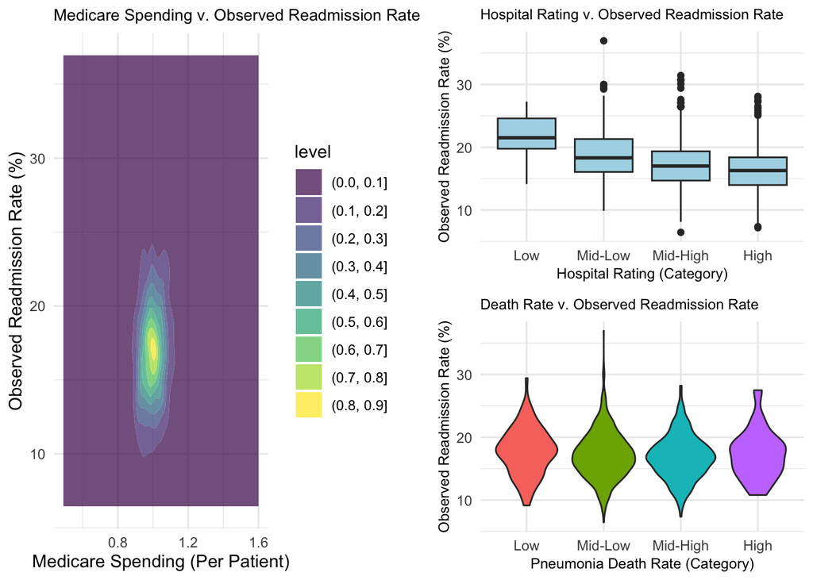

```r
# Greg A.

library(patchwork) # A library used to created faceted plots
library(cowplot)

# Modify data for plotting
pneumoniaAnalyze2 <- pneumoniaAnalyze %>% # Create pneumoniaAnalyze2
  mutate( # Confirm numeric values of columns
    `Score_Medicare spending per patient` = as.numeric(`Score_Medicare spending per patient`),
    observed_readmission_rate = as.numeric(observed_readmission_rate),
    `HcahpsLinearMeanValue_Overall hospital rating` = as.numeric(`HcahpsLinearMeanValue_Overall hospital rating`),
    `Score_Death rate for pneumonia patients` = as.numeric(`Score_Death rate for pneumonia patients`)
  ) %>%
  filter( # Filter out NA values for plotting
    is.finite(`Score_Medicare spending per patient`),
    is.finite(observed_readmission_rate),
    is.finite(`HcahpsLinearMeanValue_Overall hospital rating`),
    is.finite(`Score_Death rate for pneumonia patients`)
  ) %>%
  mutate( # Bin values for plotting
    rating_cat = cut(`HcahpsLinearMeanValue_Overall hospital rating`, breaks = 4, labels = c("Low", "Mid-Low", "Mid-High", "High")),
    death_rate_cat = cut(`Score_Death rate for pneumonia patients`, breaks = 4, labels = c("Low", "Mid-Low", "Mid-High", "High"))
  )

# Plot 1: Density Plot - Medicare Spending v. Observed Readmission Rate
p1 <- ggplot(pneumoniaAnalyze, aes(x = `Score_Medicare spending per patient`, y = observed_readmission_rate)) +
  geom_density_2d_filled(alpha = 0.7) +
  labs( # Define title and axis labels
    title = "Medicare Spending v. Observed Readmission Rate",
    x = "Medicare Spending (Per Patient)",
    y = "Observed Readmission Rate (%)"
  ) +
  theme_minimal() + theme(plot.title = element_text(size = 10))

# Plot 2: Box Plot - Hospital Rating v. Observed Readmission Rate
p2 <- ggplot(pneumoniaAnalyze2, aes(x = rating_cat, y = observed_readmission_rate)) +
  geom_boxplot(fill = "lightblue") +
  labs(title = "Hospital Rating v. Observed Readmission Rate", x = "Hospital Rating (Category)", y = "Observed Readmission Rate (%)") + # Define title and axis labels
  theme_minimal() + theme(plot.title = element_text(size = 9), axis.title.x = element_text(size = 9), axis.title.y = element_text(size = 9))

# Plot 3: Violin Plot - Pneumonia Death Rate v. Observed Readmission Rate
p3 <- ggplot(pneumoniaAnalyze2, aes(x = death_rate_cat, y = observed_readmission_rate, fill = death_rate_cat)) +
  geom_violin() +
  labs( # Define title and axis labels
    title = "Death Rate v. Observed Readmission Rate",
    x = "Pneumonia Death Rate (Category)",
    y = "Observed Readmission Rate (%)"
  ) +
  theme_minimal() + theme(plot.title = element_text(size = 9), axis.title.x = element_text(size = 9), axis.title.y = element_text(size = 9)) +
  guides(fill = "none")

# Arrange plots together

# Optionally, add extra left margin to p2 and p3
p2 <- p2 + theme(plot.margin = unit(c(5.5, 5.5, 5.5, 20), "pt"))
p3 <- p3 + theme(plot.margin = unit(c(5.5, 5.5, 5.5, 20), "pt"))

# Stack p2 and p3 vertically
right_side <- plot_grid(p2, p3, ncol = 1, align = "v", rel_heights = c(1, 1))

# Combine p1 and right_side horizontally
final_plot <- plot_grid(
  p1, right_side,
  ncol = 2,
  rel_widths = c(1, 1) # adjust as needed for your preferred proportions
)

print(final_plot)
```

Lastly, make sure to **interpret** your graphic.

> Greg A. These three plots compare the target variable to three other variables.

> The desity plot compares our target to Medicare Spending per Patient. This plot would show if higher or lower medicare spending had an impact on the observed readmission rate. However, the density levels all seem to be centered around the 1.0 mark. This might make sense, as we are looking at a single condition (pneumonia) which could simply have similar spending for each patient.

> The boxplot compares our target to hospital rating categories. We have divided the ratings into separate categories which group together similar ratings. As one might expect, the low rated hospitals see a higher observed readmission rate than the higher rated hospitals. This would help support the idea that hospitals that are rated higher are better at treating conditions and preventing the need for readmissions. Therefore, it might be useful to compare other statistics between these hospital ratings to see how they differ.

> The violin plot compares our target to penumonia death rates. We have divided the death rates into separate categories which group together similar rates. All four categories for death rates appear to have similar probabilities for observed readmission rates between 15% and 20%. > The Mid-Low category shows the greatest range across target percentages, but demonstrates these cases in very low amounts. Both the Low and the High categories have majority values slightly higher than the other two categories, bordering closer to 20% than 15%. Overall, while there are some slight differences, it does not appear as if death rate shows a great difference in observed readmission rate.

# References

De Alba, Israel, and Alpesh Amin. 2014. “Pneumonia Readmissions: Risk Factors and Implications.” *Ochsner Journal* 14 (4): 649–54.

R Core Team. 2019. *R: A Language and Environment for Statistical Computing*. Vienna, Austria: R Foundation for Statistical Computing. https://www.R-project.org.

Wickham, Hadley. 2014. “Tidy Data.” *Journal of Statistical Software* 59 (10): 1–23. https://doi.org/10.18637/jss.v059.i10.